# How to achieve quick success of a bike-sharing business?

Alfredo Muñoz Gutierrez

## Introduction

You are a junior data analyst working on the team of marketing analysts at Cyclistic, a Chicago bike-sharing company. The director of marketing believes that the future success of the company depends on maximizing the number of annual memberships. Therefore, your team wants to **understand what differences exist in the use of Cyclistic bicycles between occasional cyclists and annual members**. Using these insights, your team will devise a new marketing strategy to convert casual riders into annual members. However, before that, Cyclistic’s executives must approve your recommendations; therefore, you must support your proposal with a compelling vision of the data and professional visualizations of it.

### Stakeholders

- **Lily Moreno:** The marketing director and your manager. Moreno is responsible for developing campaigns and initiatives to promote the shared bike program. Campaigns can include email, social media, and other channels.
- **Cyclistic Executive Team:** The highly detailed executive team will decide whether to approve the recommended marketing program.

### Business task

Find insights in the Cyclistic’s bike-sharing data about different behaviors and patterns between annual members and occasional clients to make recommendations that help Moreno design marketing strategies aimed at converting occasional cyclists into annual members. Present the insights and recommendations in compelling visualizations that effectively describes the data and how you came to those conclusions to the executive team.

## Data Preparation

I use Cyclistic’s historical ride data to analyze and identify trends. I downloaded the last 12 months of Cyclistic’s travel data (Note: The datasets have a different name because Cyclistic is a fictitious company. For the purposes of this case study, the datasets are appropriate and allow me to answer the company’s questions).

### Sources

- https://divvy-tripdata.s3.amazonaws.com/index.html (Data downloaded from November 2021 to October 2022)
- https://ride.divvybikes.com/data-license-agreement (License to use the data provided by Motivate International Inc.)

### Description

The data is stored in csv files and each file has one month of data, being 12 csv files for the last year of data. The datasets have info about:

- Bike type (classic bike, electrical bike or docked bike)
- Trip start’s timestamp, station name and coordinates
- Trip end’s timestamp, station name and coordinates
- Rider status (casual or annual member)

### Data integrity

Some rows have missing values in the start station name and id as well as in the end station fields. This could be handled in different ways either removing the rows with missing data or try to fill the missing values, but this task will be addressed in the cleaning step.

### Data privacy

For data privacy reasons, it is forbidden to use personally identifiable information about riders. This means it is not permitted to connect pass purchases to credit card numbers to determine if occasional cyclists live in Cyclistic’s service area or if they purchased multiple passes for a single ride.

## Data Cleaning

I made the analysis in R since the datasets contains a high volume of data (more than 100,000 rows) use spreadsheets would not have been a good option. SQL could be a good option, but R has tools to create reports and visualizations which allows to carry out the complete analysis with a more uniform result.

### Importing the data

First I load the libraries required for this analysis, `tidyverse` library to clean, tidy and plot the data, and `lubridate` to make operations with dates. Then I imported the bicycle rides csv files for the last 12 months and merge all the datasets into one.

```r
# Importing libraries and csv files
library(tidyverse)
library(lubridate)

trips_data <- list.files(path='C:/Users/sams/Documents/R/Bycicles Project/Data') %>%
  lapply(read_csv, show_col_types = FALSE) %>%
  bind_rows
```

Now having all the data together the next step is inspect the dataset in order to know about its content and find possible issues about data integrity.

```r
#Inspect dataframe
str(trips_data)
```

```
spec_tbl_df [5,755,694 × 13] (S3: spec_tbl_df/tbl_df/tbl/data.frame)
 $ ride_id           : chr [1:5755694] "7C00A93E10556E47" "90854840DFD508BA" "0A7D10CDD144061C" "2F3BE33085BCFF02" ...
 $ rideable_type     : chr [1:5755694] "electric_bike" "electric_bike" "electric_bike" "electric_bike" ...
 $ started_at        : POSIXct[1:5755694], format: "2021-11-27 13:27:38" "2021-11-27 13:38:25" ...
 $ ended_at          : POSIXct[1:5755694], format: "2021-11-27 13:46:38" "2021-11-27 13:56:10" ...
 $ start_station_name: chr [1:5755694] NA NA NA NA ...
 $ start_station_id  : chr [1:5755694] NA NA NA NA ...
 $ end_station_name  : chr [1:5755694] NA NA NA NA ...
 $ end_station_id    : chr [1:5755694] NA NA NA NA ...
 $ start_lat         : num [1:5755694] 41.9 42 42 41.9 41.9 ...
 $ start_lng         : num [1:5755694] -87.7 -87.7 -87.7 -87.8 -87.6 ...
 $ end_lat           : num [1:5755694] 42 41.9 42 41.9 41.9 ...
 $ end_lng           : num [1:5755694] -87.7 -87.7 -87.7 -87.8 -87.6 ...
 $ member_casual     : chr [1:5755694] "casual" "casual" "casual" "casual" ...
 - attr(*, "spec")=
  .. cols(
  ..   ride_id = col_character(),
  ..   rideable_type = col_character(),
  ..   started_at = col_datetime(format = ""),
  ..   ended_at = col_datetime(format = ""),
  ..   start_station_name = col_character(),
  ..   start_station_id = col_character(),
  ..   end_station_name = col_character(),
  ..   end_station_id = col_character(),
  ..   start_lat = col_double(),
  ..   start_lng = col_double(),
  ..   end_lat = col_double(),
  ..   end_lng = col_double(),
  ..   member_casual = col_character()
  .. )
 - attr(*, "problems")=<externalptr>
```

```r
head(trips_data)
```

| ride_id | rideable_type | started_at | ended_at | start_station_name | start_station_id | end_station_name | end_station_id | start_lat | start_lng | end_lat | end_lng | member_casual |
| --- | --- | --- | --- | --- | --- | --- | --- | --- | --- | --- | --- | --- |
| 7C00A93E10556E47 | electric_bike | 2021-11-27 13:27:38 | 2021-11-27 13:46:38 | NA | NA | NA | NA | 41.93000 | -87.72000 | 41.96 | -87.73 | casual |
| 90854840DFD508BA | electric_bike | 2021-11-27 13:38:25 | 2021-11-27 13:56:10 | NA | NA | NA | NA | 41.96000 | -87.70000 | 41.92 | -87.70 | casual |
| 0A7D10CDD144061C | electric_bike | 2021-11-26 22:03:34 | 2021-11-26 22:05:56 | NA | NA | NA | NA | 41.96000 | -87.70000 | 41.96 | -87.70 | casual |
| 2F3BE33085BCFF02 | electric_bike | 2021-11-27 09:56:49 | 2021-11-27 10:01:50 | NA | NA | NA | NA | 41.94000 | -87.79000 | 41.93 | -87.79 | casual |
| D67B4781A19928D4 | electric_bike | 2021-11-26 19:09:28 | 2021-11-26 19:30:41 | NA | NA | NA | NA | 41.90000 | -87.63000 | 41.88 | -87.62 | casual |
| 02F85C2C3C5F7D46 | electric_bike | 2021-11-26 18:34:07 | 2021-11-26 18:52:49 | Michigan Ave & Oak St | 13042 | NA | NA | 41.90086 | -87.62379 | 41.90 | -87.63 | casual |

```r
summary(trips_data)
```

```
   ride_id          rideable_type        started_at
 Length:5755694     Length:5755694     Min.   :2021-11-01 00:00:14.00
 Class :character   Class :character   1st Qu.:2022-04-27 16:40:09.00
 Mode  :character   Mode  :character   Median :2022-06-30 18:31:03.00
                                       Mean   :2022-06-13 23:04:32.59
                                       3rd Qu.:2022-08-24 19:52:19.75
                                       Max.   :2022-10-31 23:59:33.00

    ended_at                      start_station_name start_station_id
 Min.   :2021-11-01 00:04:06.00   Length:5755694     Length:5755694
 1st Qu.:2022-04-27 16:51:40.25   Class :character   Class :character
 Median :2022-06-30 18:49:28.00   Mode  :character   Mode  :character
 Mean   :2022-06-13 23:23:58.99
 3rd Qu.:2022-08-24 20:10:05.75
 Max.   :2022-11-07 04:53:58.00

 end_station_name   end_station_id       start_lat       start_lng
 Length:5755694     Length:5755694     Min.   :41.64   Min.   :-87.84
 Class :character   Class :character   1st Qu.:41.88   1st Qu.:-87.66
 Mode  :character   Mode  :character   Median :41.90   Median :-87.64
                                       Mean   :41.90   Mean   :-87.65
                                       3rd Qu.:41.93   3rd Qu.:-87.63
                                       Max.   :45.64   Max.   :-73.80

    end_lat         end_lng       member_casual
 Min.   :41.39   Min.   :-88.97   Length:5755694
 1st Qu.:41.88   1st Qu.:-87.66   Class :character
 Median :41.90   Median :-87.64   Mode  :character
 Mean   :41.90   Mean   :-87.65
 3rd Qu.:41.93   3rd Qu.:-87.63
 Max.   :42.37   Max.   :-87.30
 NA's   :5835    NA's   :5835
```

```r
#Count unique and missing values
sapply(trips_data, function(x) n_distinct(x))
```

```
           ride_id      rideable_type         started_at           ended_at
           5755694                  3            4824622            4836310
start_station_name   start_station_id   end_station_name     end_station_id
              1640               1307               1664               1315
         start_lat          start_lng            end_lat            end_lng
            635025             600660             122100             118789
     member_casual
                 2
```

```r
sapply(trips_data, function(x) sum(is.na(x)))
```

```
           ride_id      rideable_type         started_at           ended_at
                 0                  0                  0                  0
start_station_name   start_station_id   end_station_name     end_station_id
            878177             878177             940010             940010
         start_lat          start_lng            end_lat            end_lng
                 0                  0               5835               5835
     member_casual
                 0
```

Inspecting the dataset I find some issues that need to be fixed:

- The rows containing info about start and end stations (name,id,latitude, longitude) have some missing values
- Since the analyze is focus on the riders behavior some columns are irrelevant.
- Some column names could have a more readable name.
- There are 3 values for `rideable_type` and there is only 2 types of bicycles(normal and electrical)

### Tidying the data

- I renamed the `rideable_type` and `member_casual` columns to `bike_type` and `customer_type` for better readability.
- For the scope of this analysis just the `bike_type`, `started_at`, `ended_at`, `start_station_name`, `end_station_name`, and `customer_type` columns are necessary so I dropped the others.
- Since “Docked_bike” and “classic_bike” are the same refer to the same bike type and I change all the “docked_bike” values to “classic_bike”.
- Having some missing values for the station names its not enough reason to drop that rows since the start and end trip time stamps are important values to the analysis so I just change the missing values to “unknown”.

```r
#Rename "rideable_type" and "member_casual" columns
trips_data_v2 <- trips_data %>%
  rename(bike_type = rideable_type, customer_type = member_casual)

#Remove unnecessary columns
trips_data_v2 <- trips_data_v2 %>%
  select(bike_type, started_at, ended_at, start_station_name,
         end_station_name, customer_type)

#Change "docked_bike" to "classic_bike"
trips_data_v2$bike_type[trips_data_v2$bike_type == "docked_bike"] <- "classic_bike"
unique(trips_data_v2$bike_type)
```

```
[1] "electric_bike" "classic_bike"
```

```r
#Fill "start_station_name" and "end_station_name" missing values with "unknown"
trips_data_v2[is.na(trips_data_v2)] <- "unknown"
```

### Adding calculated columns

I calculated the trip time with the `ended_at` and `started_ad` columns in the `trip_length` column in order to use this metric to compare casual users and members behavior. I also added columns with the date, week day and month info to be able to aggregate the data by different time measurement.

The created `trip_lenght` is measure in seconds and has a difftime datatype. For be able to make numeric operations with that column I converted it to numeric and change the units to minutes to work with most understandable units fo measurement.

```r
#Create "trip_length", "date", "day", "week_day", "month", and "year" columns
trips_data_v2 <- trips_data_v2 %>%
  mutate(trip_length = ended_at - started_at,
         date = as.Date(started_at),
         week_day = wday(started_at),
         month = format(as.Date(started_at), "%m"))


#Convert trip_length to numeric and change unit of measurement to minutes
str(trips_data_v2$trip_length)
```

```
 'difftime' num [1:5755694] 1140 1065 142 301 ...
 - attr(*, "units")= chr "secs"
```

```r
trips_data_v2$trip_length <- round(as.numeric(trips_data_v2$trip_length)/60, 1)
```

### Dropping bad data

Inspecting the `trip_length` column I found negative values, this not make sense as the trip duration can’t be less than 0 so this values should be dropped. Also I found that there are values smaller than 1 and this is very rare since it means that the trip last just a few seconds, most if this unusual data points has the same start and end station so it or they are “unknown” so that trips were test trips from the company or users that cancel the trip and return the bike. To exclude all this bad values I filter the dataset to include only rows with a `trip_length` value equal or higher than 1.

```r
#Drop rows with trip_length less than 1
trips_data_v2 <- trips_data_v2[trips_data_v2$trip_length >= 1,]
```

Now that we have already cleaned the data the next step is make a exploratory data analysis to find the insights.

## Data Analyze

First I made a descriptive analysis in the `trip_length` to know about the distribution of its values. I called the `summary` function to determine the minimum, 1st quartile, median, mean, 3rd quartile and maximum.

```r
#Trip length descriptive analysis
summary(trips_data_v2$trip_length)
```

```
    Min.  1st Qu.   Median     Mean  3rd Qu.     Max.
    1.00     6.10    10.60    19.83    18.90 41387.20
```

### Removing outliers

Looking at the summary statistics of `trip_length` we can see that the max values is *41387.20*, a very high value comparing with the mean and median.It seems like there are other unusual high values that makes the mean almost twice the median with values of *19.83* and *10.6* respectively.

```r
#Remove outliers
upper_bound = median(trips_data_v2$trip_length) + 1.5 * IQR(trips_data_v2$trip_length)
trips_data_v2 = trips_data_v2 %>% filter(trip_length <= upper_bound)
```

### Exploring the data

To know more about the customers behavior I made a histogram of the trip duration in order to find its distribution and what is the most common trip duration for members and casual users.

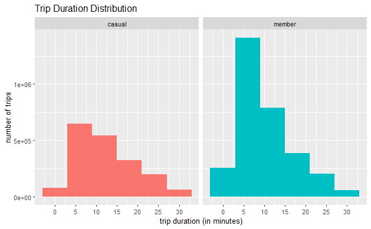

```r
#Plot trip length histogram by customer type
trips_data_v2 %>% ggplot(aes(x=trip_length, fill=customer_type)) +
  geom_histogram(binwidth = 6, show.legend=FALSE) +
  labs(title="Trip Duration Distribution", x="trip duration (in minutes)",
       y="number of trips", fill="Customer Type") +
  facet_wrap(~customer_type) +
  scale_x_continuous(breaks = seq(0,30, by=5))
```

From the histograms we can see that most of the customers use bikes for 5 to 10 minutes, both members and casual users.

Now that the outliers were removed I calculated the min, median, mean, and max values of `trip_length` by customer type.

```r
#Compare casual users and members trip length summary statistics
stats_data <- trips_data_v2 %>% group_by(customer_type) %>%
  summarise(min = min(trip_length), median = median(trip_length),
            mean = mean(trip_length), max = max(trip_length))
stats_data
```

| customer_type | min | median | mean | max |
| --- | --- | --- | --- | --- |
| casual | 1 | 11.0 | 12.38223 | 29.7 |
| member | 1 | 8.4 | 10.14373 | 29.7 |

We can see that median and mean are higher for casual users, this means that casual users use to have longest trip duration.

### Agreggating Data

From the last step we know he mean trip duration for the last 12 months for each customer type but we can know more about the users behavior change over the year if we also calculate the number of trips and aggregate the data by customer type and date.

```r
#Get the average trip time and number of trips by date
daily_data <- trips_data_v2 %>%
  group_by(date, customer_type) %>%
  summarise(number_of_trips = n(), average_duration = mean(trip_length))
daily_data
```

| date | customer_type | number_of_trips | average_duration |
| --- | --- | --- | --- |
| 2021-11-01 | casual | 3439 | 11.336580 |
| 2021-11-01 | member | 9778 | 9.070444 |
| 2021-11-02 | casual | 3242 | 10.867397 |
| 2021-11-02 | member | 10545 | 9.083509 |
| 2021-11-03 | casual | 3255 | 10.901198 |
| 2021-11-03 | member | 10554 | 9.203487 |
| 2021-11-04 | casual | 3495 | 10.712446 |
| 2021-11-04 | member | 10560 | 9.079205 |
| 2021-11-05 | casual | 4608 | 11.423741 |
| 2021-11-05 | member | 10252 | 9.394606 |

[output cut: 720 more lines]

I also aggregated the trip duration and number of trips by week day to know the changes in this metrics over the week and get insights about which days of the week have more or less trips and trip duration.

```r
#Get the average trip time and number of trips by week day
week_data <- trips_data_v2 %>%
  group_by(week_day, customer_type) %>%
  summarise(number_of_trips = n(), average_duration = mean(trip_length))
week_data
```

| week_day | customer_type | number_of_trips | average_duration |
| --- | --- | --- | --- |
| 1 | casual | 297064 | 13.151963 |
| 1 | member | 352469 | 10.650306 |
| 2 | casual | 223512 | 12.186775 |
| 2 | member | 449781 | 9.852265 |
| 3 | casual | 218357 | 11.714787 |
| 3 | member | 484529 | 9.875026 |
| 4 | casual | 230268 | 11.739031 |
| 4 | member | 489737 | 9.956818 |
| 5 | casual | 254755 | 11.836002 |
| 5 | member | 491661 | 10.000986 |

[output cut: 4 more lines]

### Most visited stations

Find what are the most visited stations by casual users is a helpful insight to know more about this customers behavior.

```r
#Get top 5 start and end stations for casual users
top_start_stations <- trips_data_v2 %>% filter(customer_type == "casual") %>%
  filter(start_station_name != "unknown") %>%
  group_by(start_station_name) %>%
  summarise(number_of_visits = n()) %>%
  arrange(-number_of_visits) %>%
  head(5)
top_start_stations
```

| start_station_name | number_of_visits |
| --- | --- |
| Streeter Dr & Grand Ave | 33199 |
| DuSable Lake Shore Dr & Monroe St | 18315 |
| DuSable Lake Shore Dr & North Blvd | 16641 |
| Michigan Ave & Oak St | 14613 |
| Wells St & Concord Ln | 14423 |

```r
top_end_stations <- trips_data_v2 %>% filter(customer_type == "casual") %>%
  filter(end_station_name != "unknown") %>%
  group_by(end_station_name) %>%
  summarise(number_of_visits = n()) %>%
  arrange(-number_of_visits) %>%
  head(5)
top_end_stations
```

| end_station_name | number_of_visits |
| --- | --- |
| Streeter Dr & Grand Ave | 32654 |
| DuSable Lake Shore Dr & North Blvd | 17428 |
| DuSable Lake Shore Dr & Monroe St | 15736 |
| Millennium Park | 15603 |
| Michigan Ave & Oak St | 14728 |

## Data Visualization

Now that we have already analyzed the data and got some metrics about users behavior the next step is to make visualizations and get insights that could help convert casual users into annual members.

### Trip duration and number of trips

First I plotted the average trip duration for members and casual users from the statistics metrics that I have already saved to the variable `stats_data`.

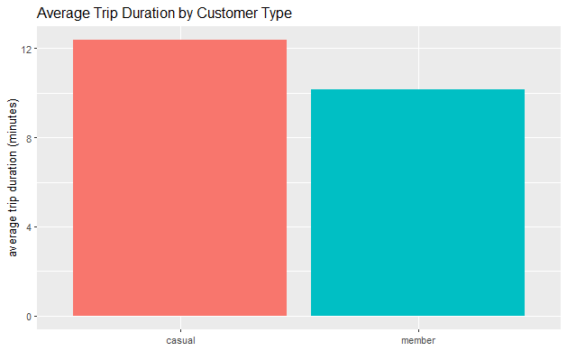

```r
#Plot average trip length by customer type
stats_data %>% ggplot(aes(x=customer_type, y=mean, fill=customer_type)) +
  geom_col(position="dodge", show.legend=FALSE) +
  labs(title="Average Trip Duration by Customer Type",
       x=NULL,y="average trip duration (minutes)")
```

Casual users have a longest average trip duration(around 12 minutes) than annual members(around 10 minutes). Let’s see how this behavior change over the year.

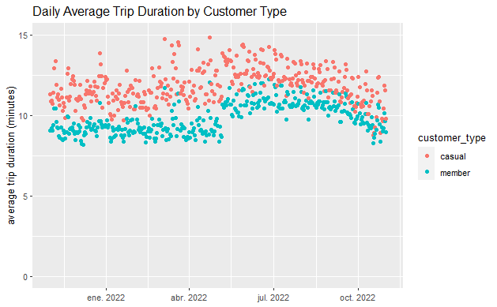

```r
#Plot average trip time by customer type and date
daily_data %>% ggplot(aes(x = date, y = average_duration, color = customer_type)) +
  geom_point() +
  labs(title = "Daily Average Trip Duration by Customer Type",
       x = NULL, y = "average trip duration (minutes)", fill = "Customer type") +
  ylim(0, 15)
```

As it can be seen in the scatter plot, trip duration does not vary much during the year and just have a little increase from June to August. The casual members have longest daily average trip duration than members all the year as it was expected from the last chart. Now let’s see the number of trips during the year.

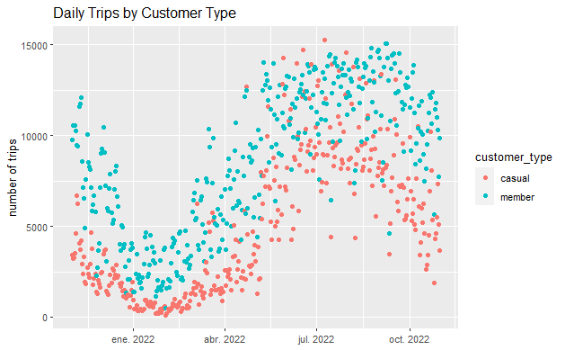

```r
#Plot number of trips by customer type and date
daily_data %>% ggplot(aes(x=date, y=number_of_trips, color=customer_type)) +
  geom_point() +
  labs(title="Daily Trips by Customer Type",
       x=NULL, y="number of trips", fill="Customer type")
```

This chart shows us that the number of users lowest is in January, then in increases until its highest in July for later decreases during the next months. We can assume that this behavior is due to the seasons of the year, being the summer the season when people tends to do more outdoors activities because of the good weather and school vacations besides winter when people tends to be more at home because of the cold weather.

Now we are going to see the differences in trip duration and number of trips by each day of the week.

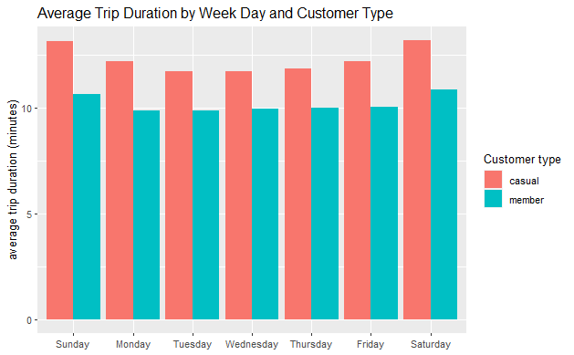

```r
#Plot average trip time by customer type and week day
week_data %>% ggplot(aes(x=week_day, y=average_duration, fill=customer_type)) +
  geom_col(position="dodge") +
  labs(title="Average Trip Duration by Week Day and Customer Type",
      x=NULL, y="average trip duration (minutes)", fill="Customer type") +
  scale_x_discrete(limits = c("Sunday", "Monday", "Tuesday", "Wednesday",
                               "Thursday", "Friday", "Saturday"))
```

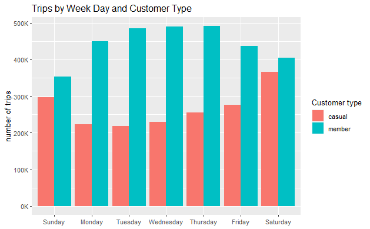

```r
#Plot number of trips by customer type and week day
week_data %>% ggplot(aes(x = week_day, y = number_of_trips/1000, fill = customer_type)) +
  geom_col(position = "dodge") +
  labs(title = "Trips by Week Day and Customer Type",
       x = NULL, y = "number of trips", fill = "Customer type") +
  scale_x_discrete(limits = c("Sunday", "Monday", "Tuesday", "Wednesday",
                              "Thursday", "Friday", "Saturday")) +
  scale_y_continuous(label = function(x) paste0(x,'K'))
```

In this graph we can see a different behavior between casual users and annual members, casual users rent bikes more often on weekends while annual members have more rides on Tuesday, Wednesday, and Thursday. This could be explained because casual users rent bikes when they have more free time (on weekends) and annual members rent bikes more often due to the preferential price.

### Most visited stations by casual users

We already have the top 5 start and end stations of casual users so we just need to plot the data to have a better glance of it.

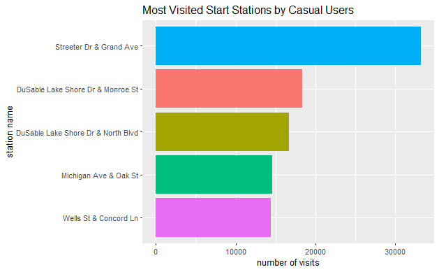

```r
#Plot top 5 start stations for casual users
ggplot(top_start_stations, aes(x=number_of_visits,
      y=forcats::fct_reorder(start_station_name, number_of_visits))) +
  geom_col(aes(fill=start_station_name), show.legend=FALSE) +
  labs(title ="Most Visited Start Stations by Casual Users",
       x="number of visits", y="station name")
```

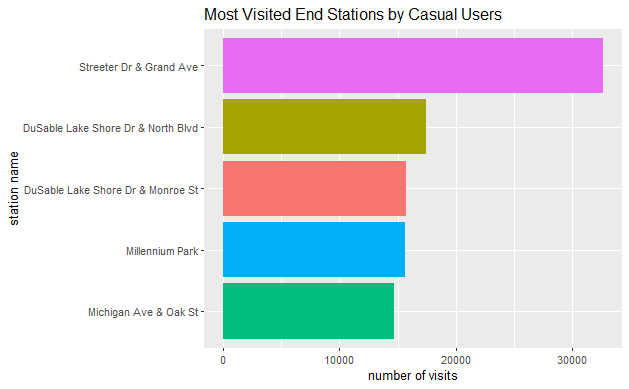

```r
#Plot top 5 end stations for casual users
ggplot(top_end_stations, aes(x=number_of_visits,
      y=forcats::fct_reorder(end_station_name, number_of_visits))) +
  geom_col(aes(fill=end_station_name), show.legend=FALSE) +
  labs(title ="Most Visited End Stations by Casual Users",
       x="number of visits", y="station name")
```

We can see that most of the top start stations are also the top end stations, this is helpful to the marketing strategy because this means that this stations are very frecuented by casual users.

### Conclusions

- Most of Cyclistic customers use bikes for 5 to 10 minutes on average, both casual users and members.
- Casual users have longer trip duration than members with an average of 12.38 minutes while member have an average of 10.14 minutes.
- The average trip duration is higher on weekends, this is true for casual users and members.
- Casual users have a higher number of trips on Friday, Saturday, and Sunday while members’ highest are on Tuesday, Wednesday, and Thursday.
- The daily average trip duration varies over a range between 8 and 15 minutes and tends to be a little bit higher on summer (June to August).
- The number of trips tends to be higher during the summer, reaching its peak in July, and lower during the winter, reaching its bottom in January.
- Casual users’ favorite stations to start or end a trip are Streeter Dr & Grand Ave, DuSable Lake Shore Dr & Monroe St, and DuSable Lake Shore Dr & North Blvd.

### Recommendations

- Offer a special discount for members only on 15 minutes or longer trips on weekends.
- Make a marketing campaign during the summer promoting a discount on memberships for new members.
- Set advertising posters promoting the membership at the stations more visited by casual users.